# Co jest lepsze - pie chart czy barplot?

Ewa Junosza-Szaniawska

2025-05-12

## Problem badawczy i ankieta

Porównuję typy wykresów - pie chart oraz barplot (grouped i stacked). Sprawdzam na ile skutecznie ludzie je odczytują i który typ wzbudza największą sympatię opinii publicznej.

W tym celu przeprowadziłam trzyetapową ankietę, którą zainteresowany czytelnik znajdzie [tutaj](https://forms.gle/DciU2ocKN2qNG3Tr6).

Wyniki ankiet, na których pracuję, są z 12 maja z 21:08.

#### Uwaga

Dane, które przedstawiają wykresy w ankiecie zostały zmyślone na potrzeby tej pracy domowej. Zbieżność czegokolwiek przypadkowa.

### Etap 1 - pytanie pomocnicze

“Wybierz jedną z opcji: a, opcja 2, inna odpowiedź”

Każdy z wyborów prowadził do innego typu wykresu na etapie 2.

#### Ciekawostka

Odpowiedzi na to pytanie rozłożyły się bardzo równomiernie, z lekką przewagą “opcji 2”:

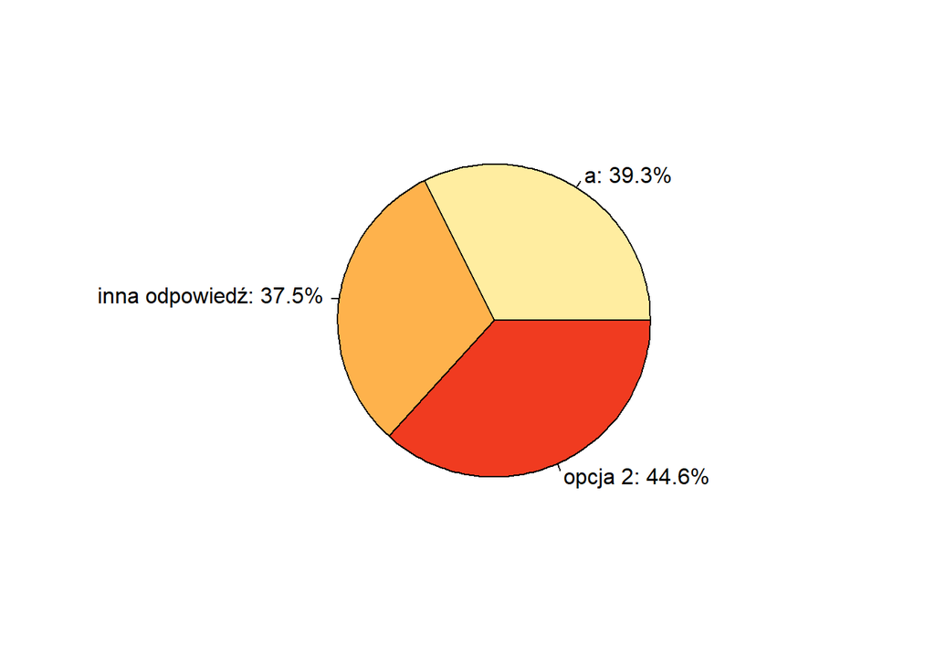

```r
etap1 <- responses %>%
  group_by(Wybierz.jedną.z.opcji) %>%
  summarize(count = n())

pie(etap1$count, labels = paste(etap1$Wybierz.jedną.z.opcji, ": ", round(etap1$count/56*100,1), "%", sep=''), col = color)
```

### Etap 2 - odczytywanie wykresu

Każdy ankietowany dostawał te same trzy pytania:

- “Gdzie jest więcej książek? brązowa szafa górna półka/brązowa szafa środkowa półka/brązowa szafa dolna półka”
- “Gdzie jest więcej książek? brązowa szafa środkowa półka/biała szafa środkowa półka/biurko dolna półka”
- “Gdzie jest mniej książek? biała szafa górna półka/biurko górna półka/biała szafa dolna półka”

i musiał na nie odpowiedzieć na podstawie jednego z poniższych wykresów:

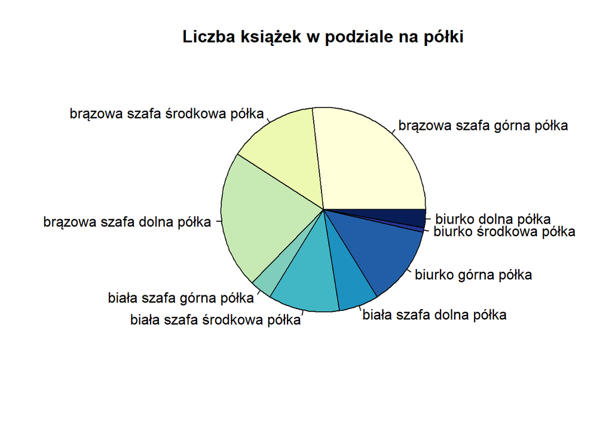

```r
pie(data$liczba, labels = paste(data$miejsce, data$półka, "półka"), col=brewer.pal(n = 9, name = "YlGnBu"), main = "Liczba książek w podziale na półki")
```

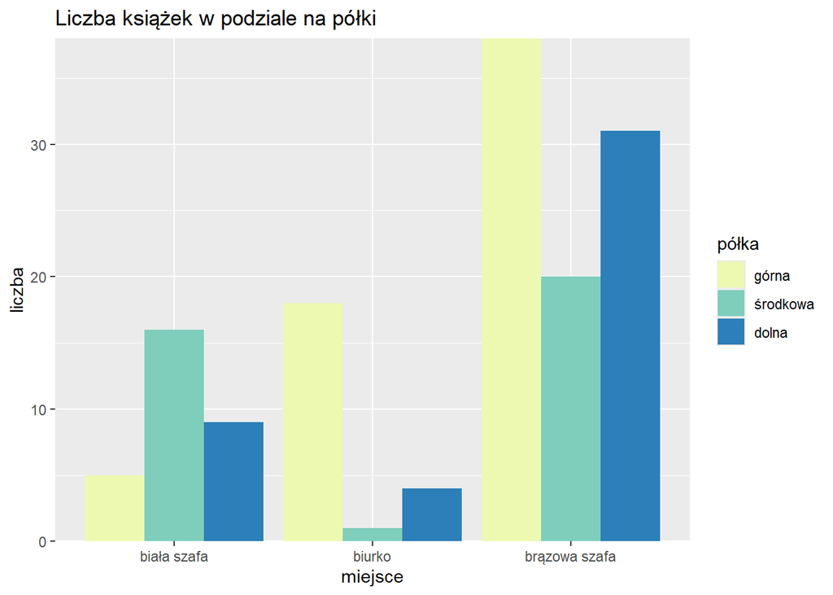

```r
data %>%
  ggplot(aes(y = liczba, x = miejsce, fill = półka)) +
  geom_bar(stat = "identity", position = "dodge") +
  scale_y_continuous(expand = c(0,0)) +
  scale_fill_manual("legend", values = brewer.pal(n = 3, name = "YlGnBu")) +
  guides(fill=guide_legend(title="półka")) +
  labs(title = "Liczba książek w podziale na półki")
```

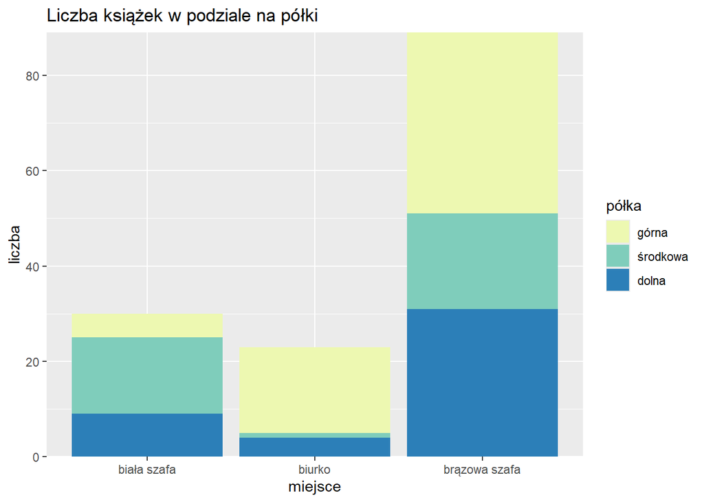

```r
data %>%
  ggplot(aes(y = liczba, x = miejsce, fill = półka)) +
  geom_bar(stat = "identity") +
  scale_y_continuous(expand = c(0,0)) +
  scale_fill_manual("legend", values = brewer.pal(n = 3, name = "YlGnBu")) +
  guides(fill=guide_legend(title="półka")) +
  labs(title = "Liczba książek w podziale na półki")
```

### Etap 3 - podsumowanie

“Który wykres Twoim zdaniem jest najbardziej czytelny? pie chart/grouped barplot/stacked barplot”

Poza tym były dwa nieobowiązkowe pytania. W jednym można było zostawić jakiś komentarz mniej więcej na temat, a w drugim wyjawić swoją tożsamość.

## Analiza

### Skuteczność w odczytywaniu wykresów

Zdecydowanie najmniej błędów robią ludzie odczytując dane z wykresu typu stacked barplot, a najwięcej - co nikogo nie dziwi - typu pie chart. Zaskakująca może być liczba niepoprawnych odpowiedzi w trzecim pytaniu przy wykresie typu grouped barplot, ale ogólnie ten typ wykresu wydaje się być raczej niezły.

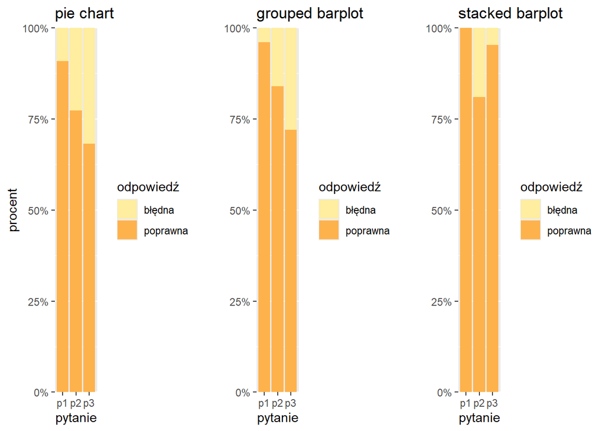

```r
pompom <- pom %>%
  mutate(p1 = ifelse(pyt1 == "brązowa szafa górna półka", "poprawna", "błędna"),
         p2 = ifelse(pyt2 == "brązowa szafa środkowa półka", "poprawna", "błędna"),
         p3 = ifelse(pyt3 == "biała szafa górna półka", "poprawna", "błędna"))

res1 <- pivot_longer(pompom, p1) %>%
  select(typ, name, value)
res2 <- pivot_longer(pompom, p2) %>%
  select(typ, name, value)
res3 <- pivot_longer(pompom, p3) %>%
  select(typ, name, value)

res <- rbind(rbind(res1, res2), res3)

plot1 <- res %>%
  filter(typ == "pie chart") %>%
  group_by(name, value) %>%
  summarize(count = n()) %>%
  ggplot(aes(y = count, x = name, fill = value)) +
  geom_bar(position = "fill", stat = "identity") +
  scale_y_continuous(expand = c(0,0), labels = scales::percent) +
  scale_fill_manual("legend", values = color) +
  labs(title = "pie chart", y = "procent", x = "pytanie") +
  guides(fill=guide_legend(title="odpowiedź"))
plot2 <- res %>%
  filter(typ == "grouped barplot") %>%
  group_by(name, value) %>%
  summarize(count = n()) %>%
  ggplot(aes(y = count, x = name, fill = value)) +
  geom_bar(position = "fill", stat = "identity") +
  scale_y_continuous(expand = c(0,0), labels = scales::percent) +
  scale_fill_manual("legend", values = color) +
  labs(title = "grouped barplot", y = "", x = "pytanie") +
  guides(fill=guide_legend(title="odpowiedź"))
plot3 <- res %>%
  filter(typ == "stacked barplot") %>%
  group_by(name, value) %>%
  summarize(count = n()) %>%
  ggplot(aes(y = count, x = name, fill = value)) +
  geom_bar(position = "fill", stat = "identity") +
  scale_y_continuous(expand = c(0,0), labels = scales::percent) +
  scale_fill_manual("legend", values = color) +
  guides(fill=guide_legend(title="odpowiedź")) +
  labs(title = "stacked barplot", y = "", x = "pytanie")

grid.arrange(plot1, plot2, plot3, ncol = 3)
```

### Prywatne preferencje

Wyraźnie widać, że największą popularnością cieszy się grouped barplot.

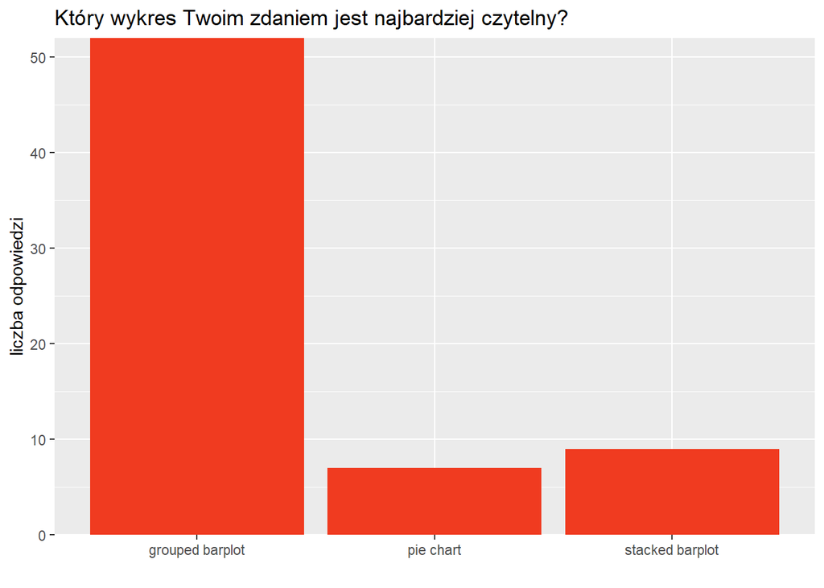

```r
responses %>%
  group_by(Który.wykres.Twoim.zdaniem.jest.najbardziej.czytelny.) %>%
  summarize(count = n()) %>%
  ggplot(aes(y = count, x = Który.wykres.Twoim.zdaniem.jest.najbardziej.czytelny.)) +
  geom_bar(stat = "identity", position = "dodge", fill = color[3]) +
  scale_y_continuous(expand = c(0,0)) +
  guides(fill=guide_legend(title="półka")) +
  labs(title = "Który wykres Twoim zdaniem jest najbardziej czytelny?",
       x = "",
       y = "liczba odpowiedzi") +
  scale_x_discrete(labels=c("pie chart (po lewej)" = "pie chart", "grouped barplot (po prawej, na górze)" = "grouped barplot", "stacked barplot (po prawej, na dole)" = "stacked barplot"))
```

Trzeba jednak dodać, że kilka osób wyraziło w pytaniu otwartym opinię, że stacked barplot jest równie dobry albo że to zależy od kontekstu i tego, co my z tamtego wykresu tak właściwie mamy odczytać.

## Wnioski

Oba rodzaje typu barplot są wyraźnie lepsze niż typ pie chart. Można na podstawie tego przypuszczać, że ludzie mają większy problem z szacowaniem kątów niż wysokości prostokątów.